# Practical Machine Learning Week 4 Project

ajibolafaki

June 19, 2018

## Introduction

Using devices such as Jawbone Up, Nike FuelBand, and Fitbit it is now possible to collect a large amount of data about personal activity relatively inexpensively. These type of devices are part of the quantified self movement - a group of enthusiasts who take measurements about themselves regularly to improve their health, to find patterns in their behavior, or because they are tech geeks. One thing that people regularly do is quantify how much of a particular activity they do, but they rarely quantify how well they do it. In this project, the goal will be to use data from accelerometers on the belt, forearm, arm, and dumbell of 6 participants. They were asked to perform barbell lifts correctly and incorrectly in 5 different ways.

## Load & Cleanse Data

```r
library(caret)
library(tidyverse)
library(randomForest)
```

```r
library(rpart)
library(rpart.plot)
library(RColorBrewer)
library(RGtk2)
library(rattle)
trainUrl <- "http://d396qusza40orc.cloudfront.net/predmachlearn/pml-training.csv"
testUrl <- "http://d396qusza40orc.cloudfront.net/predmachlearn/pml-testing.csv"
training_df <- read.csv(url(trainUrl), na.strings=c("NA","#DIV/0!",""))
testing_df  <- read.csv(url(testUrl), na.strings=c("NA","#DIV/0!",""))

# Exclude first seven variables because they are not predictors
#str(training_df)
training_df <- training_df[, -c(1:7)]

# Exclude columns with NAs from training dataset
training_df <- training_df[, colSums(is.na(training_df)) == 0]

# Check for near zero variance in training dataset
training_nzv <- nzv(training_df[,-ncol(training_df)],saveMetrics=TRUE)
#rownames(training_nzv)


# partition training dataset further into train and test data sets
inTrain  <- createDataPartition(training_df$classe, p=0.75, list=FALSE)
train_df <- training_df[inTrain, ]
test_df  <- training_df[-inTrain, ]

dim(train_df)
dim(test_df)
```

[output not shown]

## Modeling : Decision Trees

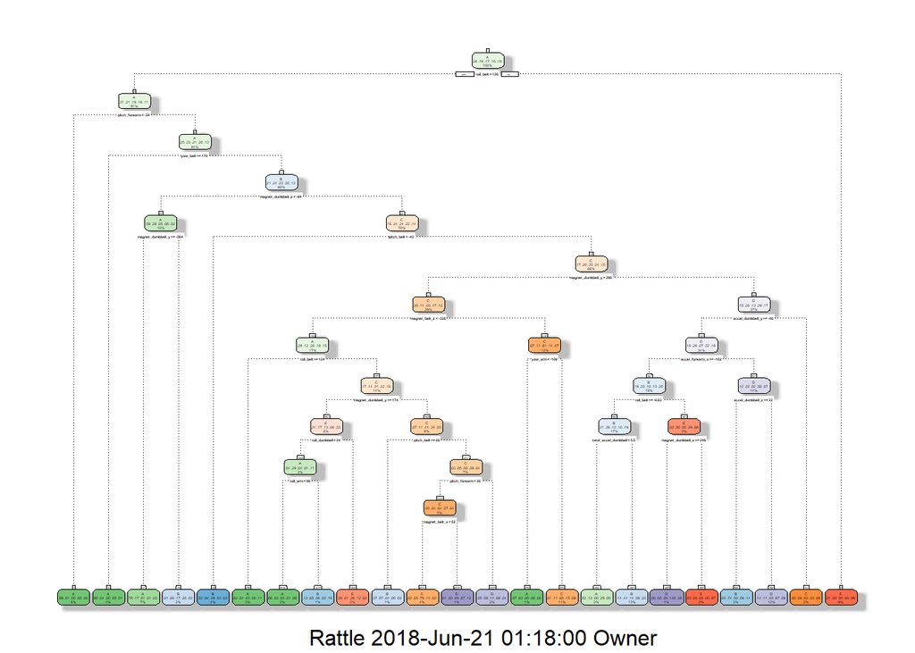

```r
set.seed(21251)
fit_dt <- rpart(classe ~ ., data = train_df, method="class")
fancyRpartPlot(fit_dt)
```

```r
predict_dt <- predict(fit_dt, test_df, type = "class")
confusionMatrix(predict_dt, test_df$classe)
```

```
## Confusion Matrix and Statistics
##
##           Reference
## Prediction    A    B    C    D    E
##          A 1162  120   11   55   40
##          B  123  682  119   94  182
##          C    8   86  637  111   57
##          D   91   60   38  523   56
##          E   11    1   50   21  566
##
## Overall Statistics
##
##                Accuracy : 0.728
##                  95% CI : (0.7153, 0.7404)
##     No Information Rate : 0.2845
##     P-Value [Acc > NIR] : < 2.2e-16
##
##                   Kappa : 0.6557
##  Mcnemar's Test P-Value : < 2.2e-16
##
## Statistics by Class:
##
##                      Class: A Class: B Class: C Class: D Class: E
## Sensitivity            0.8330   0.7187   0.7450   0.6505   0.6282
## Specificity            0.9356   0.8690   0.9353   0.9402   0.9793
## Pos Pred Value         0.8372   0.5683   0.7086   0.6810   0.8721
## Neg Pred Value         0.9337   0.9279   0.9456   0.9321   0.9213
## Prevalence             0.2845   0.1935   0.1743   0.1639   0.1837
## Detection Rate         0.2369   0.1391   0.1299   0.1066   0.1154
## Detection Prevalence   0.2830   0.2447   0.1833   0.1566   0.1323
## Balanced Accuracy      0.8843   0.7938   0.8402   0.7954   0.8037
```

## Modeling : Random Forest

```r
set.seed(21212)
fit_rf <- randomForest(classe ~ ., data = train_df, ntree = 1000)
predict_rf <- predict(fit_rf, test_df, type = "class")
confusionMatrix(predict_rf, test_df$classe)
```

```
## Confusion Matrix and Statistics
##
##           Reference
## Prediction    A    B    C    D    E
##          A 1392    5    0    0    0
##          B    3  943    5    0    0
##          C    0    1  849    9    1
##          D    0    0    1  795    2
##          E    0    0    0    0  898
##
## Overall Statistics
##
##                Accuracy : 0.9945
##                  95% CI : (0.992, 0.9964)
##     No Information Rate : 0.2845
##     P-Value [Acc > NIR] : < 2.2e-16
##
##                   Kappa : 0.993
##  Mcnemar's Test P-Value : NA
##
## Statistics by Class:
##
##                      Class: A Class: B Class: C Class: D Class: E
## Sensitivity            0.9978   0.9937   0.9930   0.9888   0.9967
## Specificity            0.9986   0.9980   0.9973   0.9993   1.0000
## Pos Pred Value         0.9964   0.9916   0.9872   0.9962   1.0000
## Neg Pred Value         0.9991   0.9985   0.9985   0.9978   0.9993
## Prevalence             0.2845   0.1935   0.1743   0.1639   0.1837
## Detection Rate         0.2838   0.1923   0.1731   0.1621   0.1831
## Detection Prevalence   0.2849   0.1939   0.1754   0.1627   0.1831
## Balanced Accuracy      0.9982   0.9958   0.9951   0.9940   0.9983
```

## Modeling : GBM

```r
set.seed(21237)
fit_gbm <- train(classe ~ ., data = train_df,
                             trControl = trainControl(method = "repeatedcv", number = 5, repeats = 1),
                             method = "gbm")
```

```r
predict_gbm <- predict(fit_gbm, test_df)
confusionMatrix(predict_gbm, test_df$classe)
```

```
## Confusion Matrix and Statistics
##
##           Reference
## Prediction    A    B    C    D    E
##          A 1377   35    0    2    4
##          B   12  893   24    2   12
##          C    4   20  820   32    5
##          D    2    1   11  766   18
##          E    0    0    0    2  862
##
## Overall Statistics
##
##                Accuracy : 0.9621
##                  95% CI : (0.9563, 0.9672)
##     No Information Rate : 0.2845
##     P-Value [Acc > NIR] : < 2.2e-16
##
##                   Kappa : 0.952
##  Mcnemar's Test P-Value : 3.612e-09
##
## Statistics by Class:
##
##                      Class: A Class: B Class: C Class: D Class: E
## Sensitivity            0.9871   0.9410   0.9591   0.9527   0.9567
## Specificity            0.9883   0.9874   0.9849   0.9922   0.9995
## Pos Pred Value         0.9711   0.9470   0.9308   0.9599   0.9977
## Neg Pred Value         0.9948   0.9859   0.9913   0.9907   0.9903
## Prevalence             0.2845   0.1935   0.1743   0.1639   0.1837
## Detection Rate         0.2808   0.1821   0.1672   0.1562   0.1758
## Detection Prevalence   0.2892   0.1923   0.1796   0.1627   0.1762
## Balanced Accuracy      0.9877   0.9642   0.9720   0.9725   0.9781
```

```r
predict_rf_final <- predict(fit_rf, testing_df, type = "class")
predict_rf_final
```

```
##  1  2  3  4  5  6  7  8  9 10 11 12 13 14 15 16 17 18 19 20
##  B  A  B  A  A  E  D  B  A  A  B  C  B  A  E  E  A  B  B  B
## Levels: A B C D E
```